# summary statistics hw

Nick Marks

7/13/2017

The homework assignment is to explore a variable in the attributes dataset. I will look at two year redemptions.

```r
describe(attributes$num_redemptions_2yr)
```

```
## attributes$num_redemptions_2yr
##        n  missing distinct
##   200000        0       59
##
## lowest : ?  0  1  10 11, highest: 7  71 77 8  9
```

There are cases with ‘?’ as a value. In case of redemptions it’s likely that customers with missing values have never redeemed a flight, so I’ll convert these cases to 0.

```r
attributes_clean <- attributes %>%
  mutate(num_redemptions_2yr = as.numeric(ifelse(num_redemptions_2yr=='?',0,num_redemptions_2yr)))

describe(attributes_clean$num_redemptions_2yr)
```

```
## attributes_clean$num_redemptions_2yr
##        n  missing distinct     Info     Mean      Gmd      .05      .10
##   200000        0       58    0.269   0.3726   0.7086        0        0
##      .25      .50      .75      .90      .95
##        0        0        0        0        2
##
## lowest :  0  1  2  3  4, highest: 57 58 60 71 77
```

These are likely customers who don’t have a loyalty account and so can’t redeem. Let’s check that out

```r
attributes_clean %>%
  group_by(loyalty_status) %>%
  summarise(min = min(num_redemptions_2yr)
            , median = median(num_redemptions_2yr)
            , mean = mean(num_redemptions_2yr)
            , n = n()) %>%
  mutate(pct = n / sum(n))
```

```
## # A tibble: 4 x 6
##     loyalty_status   min median       mean      n      pct
##              <chr> <dbl>  <dbl>      <dbl>  <int>    <dbl>
## 1           a-list     0      4  5.8199052   1477 0.007385
## 2 a-list preferred     0     12 14.9836661    551 0.002755
## 3       non-member     0      0  0.0000000  86764 0.433820
## 4        rr member     0      0  0.5185328 111208 0.556040
```

My suspicion is confirmed. Non-members have never redeemed a flight, and these customers make up 43% of the population.

Let’s look at the overall distribution of this variale

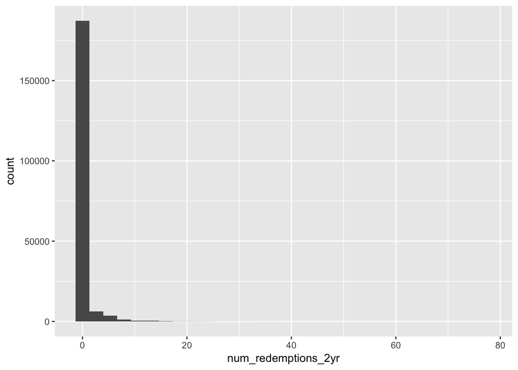

```r
ggplot(attributes_clean, aes(num_redemptions_2yr)) +
  geom_histogram()
```

The vast majority of customers have never redeemed a flight in the past two years. So next I’ll just look at customer who have redeemed

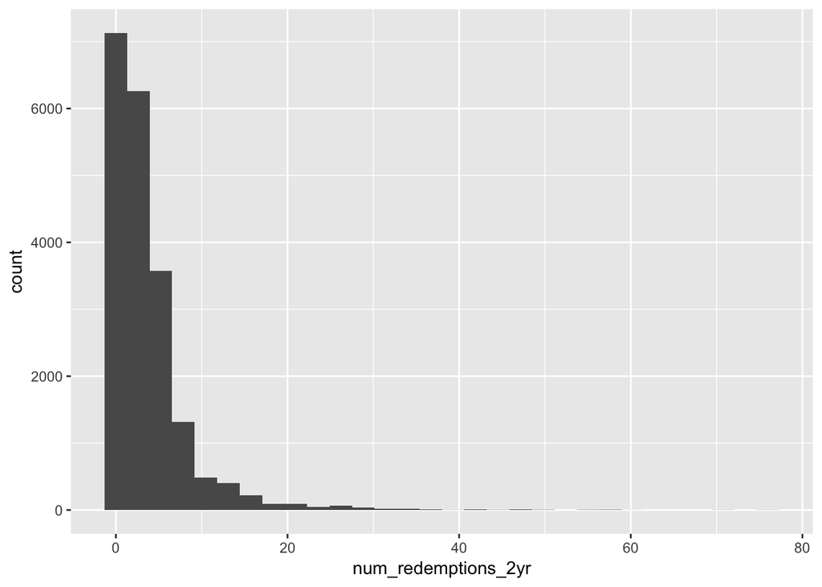

```r
ggplot(attributes_clean %>% filter(num_redemptions_2yr>0), aes(num_redemptions_2yr)) +
  geom_histogram()
```

Even in this scenario the distribution is very right skewed.

Next I’ll look at how these distributions vary by loyalty_status, first getting the data into a tidy form that’s easier to analyze and plot

```r
attributes_tidy <- attributes_clean %>%
  select(fake_id, SEGMENT_ASSIGNED, loyalty_status, num_redemptions_2yr) %>%
  gather(attribute, value, -fake_id, -SEGMENT_ASSIGNED, -loyalty_status)
```

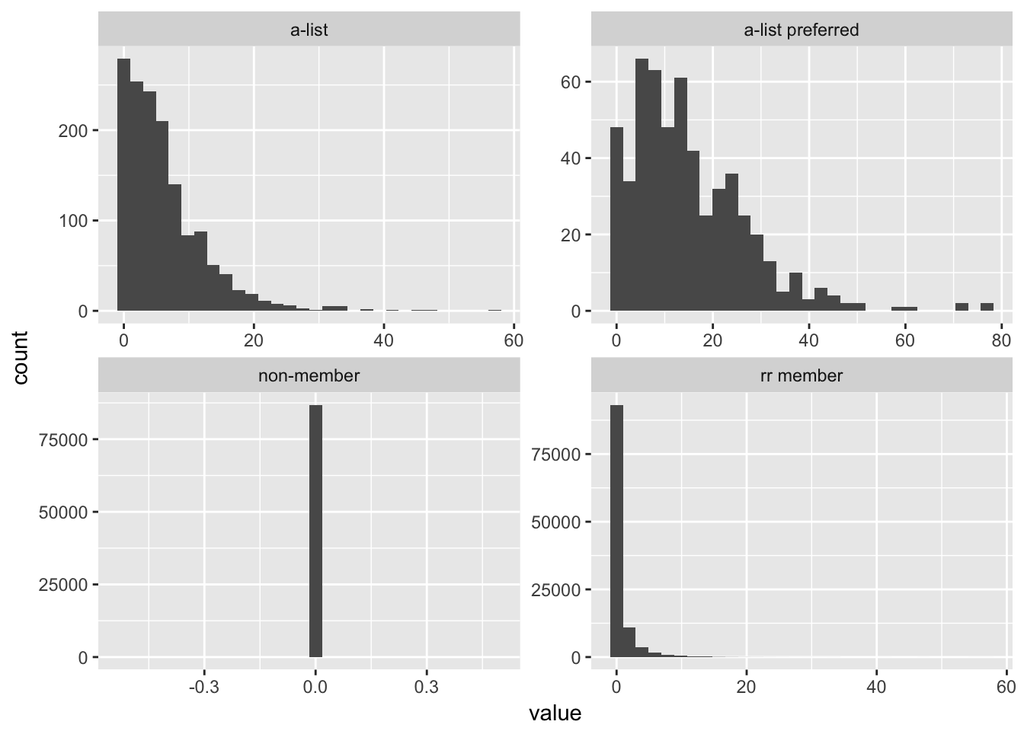

```r
attributes_tidy %>%
  ggplot(aes(value)) %+%
  geom_histogram() %+%
  facet_wrap(~loyalty_status, scales = "free")
```

We see that all non-members have never redeemed and that the skewness of the redeemption distribution declines as we move from the general populatoin “rr member” to the most frequent travelers “a-list prefered”